# svm01xht: Support Vector Machine (SVM) for Binary Classification with Hypothesis Testing Utilities

Vincent, Boer 123040049@link.cuhk.edu.cn and Adrian, Kristanto 123040001@link.cuhk.edu.cn

## Setup

In this documentation, the “loan_dataset.rda” will be used to provide demonstrations of the functions. First, let’s have a look at the dataset.

```r
library(svm01xht)

dataset = loan_dataset
names(dataset)
```

```
#>  [1] "person_age"                     "person_gender"
#>  [3] "person_education"               "person_income"
#>  [5] "person_emp_exp"                 "person_home_ownership"
#>  [7] "loan_amnt"                      "loan_intent"
#>  [9] "loan_int_rate"                  "loan_percent_income"
#> [11] "cb_person_cred_hist_length"     "credit_score"
#> [13] "previous_loan_defaults_on_file" "loan_status"
```

```r
dataset[sample(1:nrow(dataset), 8), ]
```

```
#>      person_age person_gender person_education person_income person_emp_exp
#> 1250         29          male      High School         18906              9
#> 2224         34          male        Associate         90120             10
#> 9773         31        female         Bachelor        127809              6
#> 8523         32          male         Bachelor         82831              7
#> 9668         25          male        Associate         97781              2
#> 261          32        female           Master         44847             10
#> 6456         24        female        Associate         25992              3
#> 1821         24          male      High School         53584              3
#>      person_home_ownership loan_amnt       loan_intent loan_int_rate
#> 1250                  RENT      2600 DEBTCONSOLIDATION         16.29
#> 2224                  RENT     11200         EDUCATION         11.66
#> 9773                  RENT     17700 DEBTCONSOLIDATION         10.99
#> 8523              MORTGAGE      2068   HOMEIMPROVEMENT         10.89
#> 9668                  RENT     18000          PERSONAL         13.92
```

[output cut: 21 more lines]

This dataset has 14 columns, consisting of 13 feature columns, and 1 label column. The feature columns consist of numeric and character data. The numeric data further consists of discrete and continuous values. The “loan_status” column is the binary label with values 0 and 1, indicating whether a loan was rejected or accepted. The goal here is to build a model to judge whether a loan should be rejected or accepted based on available feature columns.

## Data Preprocessing

Before doing data preprocessing, it is helpful to have a look at the distribution of the data to understand the data and decide which features are useful in creating a model. The `plot_hist` function can be used to plot the histogram of feature columns in the data. For example:

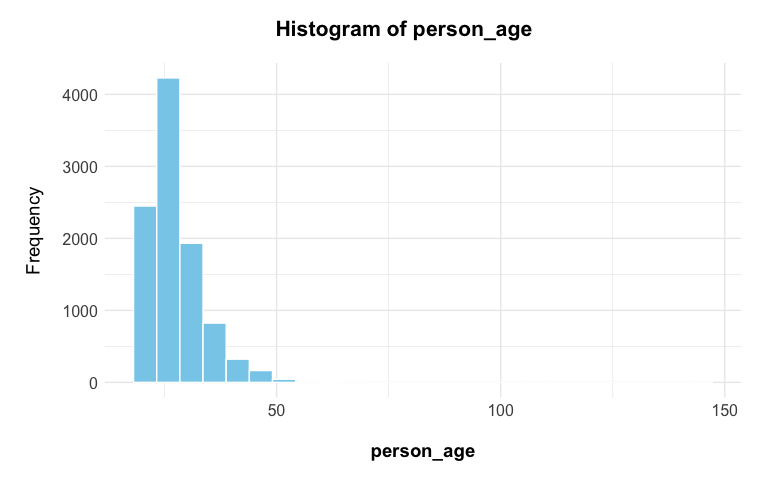

```r
plot_hist(dataset, "person_age")
```

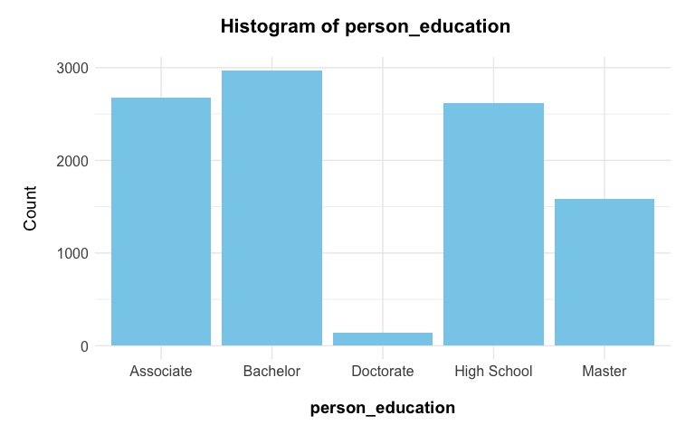

```r
plot_hist(dataset, "person_education")
```

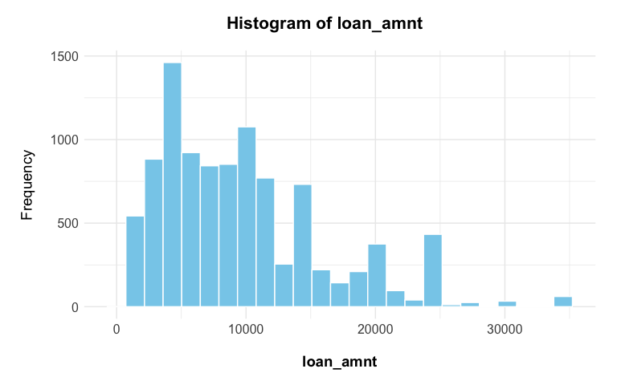

```r
plot_hist(dataset, "loan_amnt")
```

Or if all feature columns needed to be plot:

```r
lapply(names(dataset), function(x) {
  plot_hist(dataset, x)
})
```

After looking at the data overview, we can begin to process the data. Feature columns that are difficult to use in modeling such as “loan_intent” can be removed for simplicity. Note that these feature columns could be transformed into forms suitable for SVM through more advanced processing methods, but such steps are beyond the scope of this package.

```r
dataset = dataset[, -which(names(dataset) %in% c("loan_intent"))]
```

Now we are left with 13 columns. Currently, the dataset has character features which cannot be used in SVM. However, we cannot simply remove all these columns. Instead, we should map some of the character feature columns to numeric feature columns. Notice that the feature columns such as “person_education” and “person_home_ownership” have values which can be scaled in a logical sense to integer. Similarly, “person_gender” and “previous_loan_defaults_on_file” are binary in character format. To convert these character columns, we can create a list that consist of logical orders of the character feature column values. The `preprocess` function will then map these character values to their index order in the list as their new representation. Other than converting character columns to numeric, the label column also need to be converted from binary 0 and 1, to -1 and 1 for SVM purpose. This can also be done in the `preprocess` function by providing the label column name or index.

```r
# Create a list which maps the character feature columns to numeric.
mapping = list(person_gender = c("male", "female"),
                person_education = c("High School", "Bachelor", "Master", "Doctorate",
                                     "Associate"),
                person_home_ownership = c("OTHER", "RENT", "MORTGAGE", "OWN"),
                previous_loan_defaults_on_file = c("No", "Yes"))

dataset = preprocess(dataset, mapping, "loan_status")

dataset[sample(1:nrow(dataset), 8), ]
```

```
#>      person_age person_gender person_education person_income person_emp_exp
#> 7295         26             1                5         90968              6
#> 1779         34             0                2        166558             14
#> 6095         25             1                3        118316              2
#> 297          27             0                3         78884              8
#> 8430         28             0                2         66851              6
#> 5394         29             0                2         51550              5
#> 1840         26             0                5         36956              2
#> 2012         22             1                1         91119              1
#>      person_home_ownership loan_amnt loan_int_rate loan_percent_income
#> 7295                     2      7000          8.90                0.08
#> 1779                     3     20951         18.65                0.13
#> 6095                     2     10000         12.69                0.08
#> 297                      2     20000         11.01                0.25
#> 8430                     3      6400         11.01                0.10
```

[output cut: 21 more lines]

The `preprocess` function automatically removes any rows with NA values and columns with unconverted character values for simplicity. It also names unnamed columns, as column names will be needed for some later functions. With the dataset now consist of only numeric feature columns and -1 and 1 label, it can now be used to train SVM models.

## SVM Model Training

The `svm` function takes numeric features and label data, and returns a list of values which represents the SVM model.

```r
data = dataset[, c(1:12)]
label = dataset[, 13]

random.train.index = sample(1:nrow(data), size = 200, replace = FALSE)

linear.model = svm(data[random.train.index, ], label[random.train.index])
linear.model
```

```
#> $w
#>                     person_age                  person_gender
#>                     0.88014593                     0.20186502
#>               person_education                  person_income
#>                    -0.19773398                    -0.03926148
#>                 person_emp_exp          person_home_ownership
#>                     0.06247602                    -0.50030128
#>                      loan_amnt                  loan_int_rate
#>                    -0.02131181                     0.61480675
#>            loan_percent_income     cb_person_cred_hist_length
#>                     0.93852331                    -0.79572701
#>                   credit_score previous_loan_defaults_on_file
#>                    -0.42045038                    -1.84789236
#>
#> $b
#> [1] -1.432743
#>
#> $type
#> [1] "linear"
#>
#> $features
#>  [1] "person_age"                     "person_gender"
#>  [3] "person_education"               "person_income"
#>  [5] "person_emp_exp"                 "person_home_ownership"
#>  [7] "loan_amnt"                      "loan_int_rate"
#>  [9] "loan_percent_income"            "cb_person_cred_hist_length"
#> [11] "credit_score"                   "previous_loan_defaults_on_file"
```

We can also decide to use random index of the data and choose feature columns for the model by providing the column names.

```r
linear.model.partial = svm(data, label, n = 200, features = names(data)[1:10])
linear.model.partial
```

```
#> $w
#>                 person_age              person_gender
#>                  0.3104736                  0.1899288
#>           person_education              person_income
#>                  0.2057927                  0.4294075
#>             person_emp_exp      person_home_ownership
#>                 -0.6989934                 -0.6804076
#>                  loan_amnt              loan_int_rate
#>                 -0.3195199                  0.7184755
#>        loan_percent_income cb_person_cred_hist_length
#>                  1.0347978                  0.1272574
#>
#> $b
#> [1] -0.7796533
#>
#> $type
#> [1] "linear"
#>
#> $features
#>  [1] "person_age"                 "person_gender"
#>  [3] "person_education"           "person_income"
#>  [5] "person_emp_exp"             "person_home_ownership"
#>  [7] "loan_amnt"                  "loan_int_rate"
#>  [9] "loan_percent_income"        "cb_person_cred_hist_length"
```

In addition to linear SVM, polynomial and rbf kernels are also supported in the `svm` function.

```r
poly.model = svm(data, label, type = "polynomial", n = 200)

rbf.model = svm(data, label, type = "rbf", n = 200)
```

## Prediction and Accuracy Test

The models can be used to predict new data using the `predict` function. The accuracy of the prediction can be directly evaluated using the `test_accuracy` function.

```r
random.test.index = sample(1:nrow(data), size = 200, replace = FALSE)

predict(linear.model, data[random.test.index, ])
```

```
#>   [1]  1 -1  1 -1 -1 -1 -1  1  1  1 -1  1  1  1  1  1 -1  1  1 -1 -1 -1 -1  1 -1
#>  [26]  1 -1  1 -1  1 -1  1  1  1  1 -1 -1  1  1 -1 -1 -1 -1  1  1 -1 -1  1  1 -1
#>  [51] -1 -1  1 -1 -1 -1 -1 -1 -1 -1 -1 -1 -1 -1  1 -1  1 -1  1  1  1  1 -1 -1 -1
#>  [76] -1 -1  1 -1 -1 -1 -1 -1 -1 -1  1 -1  1 -1 -1 -1 -1  1  1 -1 -1 -1  1 -1  1
#> [101] -1 -1 -1 -1 -1  1 -1 -1 -1 -1 -1 -1 -1 -1  1 -1 -1 -1  1 -1  1 -1 -1 -1 -1
#> [126] -1  1  1  1 -1 -1 -1 -1  1 -1  1 -1 -1 -1  1 -1 -1 -1 -1  1 -1  1 -1 -1 -1
#> [151] -1 -1 -1  1 -1 -1 -1 -1 -1 -1 -1  1 -1 -1  1 -1 -1 -1 -1 -1  1 -1 -1 -1  1
#> [176] -1  1 -1  1 -1 -1  1 -1 -1  1 -1  1 -1 -1 -1  1 -1 -1 -1 -1 -1 -1  1 -1  1
```

```r
test_accuracy(linear.model, data[random.test.index, ], label[random.test.index])
```

```
#> [1] 0.845
```

```r
predict(linear.model.partial, data[random.test.index, ])
```

```
#>   [1]  1 -1 -1  1 -1  1  1 -1  1  1 -1 -1 -1  1 -1  1 -1 -1 -1 -1 -1 -1 -1  1  1
#>  [26]  1 -1 -1 -1 -1 -1 -1 -1 -1 -1 -1 -1 -1  1 -1 -1 -1 -1 -1 -1 -1 -1  1  1 -1
#>  [51] -1  1  1  1 -1 -1 -1 -1 -1 -1 -1 -1 -1 -1  1 -1  1  1  1  1  1  1  1  1 -1
#>  [76] -1 -1  1 -1 -1 -1  1 -1 -1 -1 -1 -1 -1 -1 -1 -1 -1 -1  1 -1 -1 -1 -1 -1  1
#> [101] -1  1 -1 -1 -1  1 -1 -1 -1  1 -1 -1 -1 -1  1 -1 -1 -1 -1 -1  1 -1 -1  1 -1
#> [126] -1 -1  1  1 -1 -1 -1 -1 -1 -1 -1 -1 -1 -1  1 -1 -1 -1 -1  1 -1  1 -1 -1  1
#> [151] -1 -1 -1 -1 -1  1 -1 -1 -1 -1 -1 -1 -1 -1  1  1 -1  1 -1 -1 -1 -1  1 -1  1
#> [176] -1 -1 -1 -1 -1 -1  1 -1 -1 -1 -1 -1 -1 -1 -1 -1  1 -1 -1 -1 -1 -1  1 -1  1
```

```r
test_accuracy(linear.model.partial, data[random.test.index, ], label[random.test.index])
```

```
#> [1] 0.77
```

```r
predict(poly.model, data[random.test.index, ])
```

```
#>   [1]  1  1  1 -1  1 -1 -1  1  1  1  1  1  1  1  1  1  1  1  1  1  1  1 -1  1  1
#>  [26]  1 -1  1  1  1 -1  1  1  1 -1 -1 -1  1  1  1  1 -1  1  1  1  1 -1  1  1  1
#>  [51]  1  1  1 -1  1  1 -1  1 -1 -1  1 -1  1  1  1  1  1 -1  1  1  1  1 -1  1  1
#>  [76]  1 -1  1  1 -1 -1  1 -1  1 -1  1  1 -1  1  1 -1 -1 -1  1 -1  1 -1  1 -1  1
#> [101]  1  1  1  1 -1  1 -1 -1  1  1  1  1 -1  1  1  1 -1  1  1 -1  1  1  1 -1  1
#> [126]  1  1 -1  1  1 -1  1 -1  1  1  1 -1  1  1  1 -1  1  1  1 -1 -1  1  1 -1  1
#> [151]  1 -1  1  1  1  1  1  1  1  1 -1 -1 -1  1  1  1  1  1  1  1  1 -1  1 -1 -1
#> [176]  1  1 -1  1 -1  1  1  1  1  1 -1  1  1  1  1  1 -1 -1 -1  1  1 -1  1 -1  1
```

```r
test_accuracy(poly.model, data[random.test.index, ], label[random.test.index])
```

```
#> [1] 0.52
```

```r
predict(rbf.model, data[random.test.index, ])
```

```
#>   [1]  1 -1  1 -1 -1 -1 -1 -1  1  1 -1 -1  1  1  1  1 -1  1  1 -1  1 -1 -1  1 -1
#>  [26]  1 -1  1 -1  1 -1  1 -1 -1  1 -1 -1 -1  1 -1 -1 -1 -1  1 -1 -1  1 -1  1 -1
#>  [51] -1 -1  1 -1 -1 -1 -1 -1 -1 -1 -1  1 -1 -1  1 -1  1 -1  1  1  1  1 -1 -1 -1
#>  [76] -1 -1  1 -1 -1 -1 -1 -1 -1 -1  1 -1 -1 -1 -1 -1 -1  1  1 -1 -1 -1  1 -1  1
#> [101] -1 -1 -1 -1 -1  1 -1 -1 -1 -1 -1 -1 -1 -1  1 -1 -1  1  1 -1  1 -1 -1 -1 -1
#> [126] -1  1  1  1 -1 -1 -1 -1  1 -1 -1 -1 -1 -1  1 -1 -1 -1 -1  1 -1  1 -1 -1 -1
#> [151] -1 -1 -1  1 -1  1 -1 -1 -1 -1 -1  1 -1  1  1 -1 -1 -1 -1 -1  1 -1 -1 -1 -1
#> [176] -1  1 -1  1 -1 -1  1 -1 -1 -1 -1  1 -1 -1 -1  1 -1 -1 -1 -1 -1 -1  1 -1  1
```

```r
test_accuracy(rbf.model, data[random.test.index, ], label[random.test.index])
```

```
#> [1] 0.87
```

## Select Correlated Features

In this example dataset, the number of features is small. However, in other datasets, number of features can be very large that feature selection should be done for efficiency. This package has `select_correlated_features` function to choose top “n” correlated features if “n” is given, or all features with absolute correlation to the label above some “min” value between 0 and 1.

```r
select_correlated_features(data, label, n = 8, show = TRUE)
```

```
#> previous_loan_defaults_on_file            loan_percent_income
#>                   0.6168032319                   0.4165565173
#>                  loan_int_rate          person_home_ownership
#>                   0.3749369445                   0.2963457108
#>                  person_income                      loan_amnt
#>                   0.1381871735                   0.1172848358
#>                 person_emp_exp                     person_age
#>                   0.0237013446                   0.0235221670
#>     cb_person_cred_hist_length                  person_gender
#>                   0.0171855859                   0.0080657054
#>                   credit_score               person_education
#>                   0.0026700750                   0.0001786851
#> [1] "previous_loan_defaults_on_file" "loan_percent_income"
#> [3] "loan_int_rate"                  "person_home_ownership"
#> [5] "person_income"                  "loan_amnt"
#> [7] "person_emp_exp"                 "person_age"
```

```r
select_correlated_features(data, label, min = 0.1)
```

```
#> [1] "person_income"                  "person_home_ownership"
#> [3] "loan_amnt"                      "loan_int_rate"
#> [5] "loan_percent_income"            "previous_loan_defaults_on_file"
```

```r
data = data[, c(select_correlated_features(data, label, n = 8))]
```

## Parameter Tuning

The parameters for the kernels and the regularization parameter of the SVM can also be adjusted to improve the model. To choose a suitable parameter for a model, we can use the `tune_parameters` function which compares the performance of models with different parameters.

```r
random.train.index = sample(1:nrow(data), size = 500, replace = FALSE)
random.test.index = sample(1:nrow(data), size = 500, replace = FALSE)

tune_parameters(data[random.train.index, ], label[random.train.index],
               data[random.test.index, ], label[random.test.index],
               type = "linear", C = c(1, 10))
```

```
#>    C training.accuracy test.accuracy
#> 1  1             0.882         0.862
#> 2 10             0.882         0.862
```

```r
tune_parameters(data[random.train.index, ], label[random.train.index],
               data[random.test.index, ], label[random.test.index],
               type = "polynomial", c = c(1, 10), degree = c(2, 3))
```

```
#>   C  c degree training.accuracy test.accuracy
#> 1 1  1      2             0.420         0.460
#> 2 1  1      3             0.788         0.750
#> 3 1 10      2             0.486         0.502
#> 4 1 10      3             0.578         0.602
```

```r
tune_parameters(data[random.train.index, ], label[random.train.index],
               data[random.test.index, ], label[random.test.index],
               type = "rbf", C = c(1, 10), gamma = c(0.1, 1))
```

```
#>    C gamma training.accuracy test.accuracy
#> 1  1   0.1             0.898         0.858
#> 2  1   1.0             0.962         0.858
#> 3 10   0.1             0.926         0.864
#> 4 10   1.0             0.992         0.862
```

```r
random.test.index = sample(1:nrow(data), size = 1000, replace = FALSE)

linear.model.tuned = svm(data, label, type = "linear", n = 1000, C = 10)
test_accuracy(linear.model.tuned, data[random.test.index, ], label[random.test.index])
```

```
#> [1] 0.874
```

```r
poly.model.tuned = svm(data, label, type = "polynomial", n = 1000, c = 10, degree = 3)
test_accuracy(poly.model.tuned, data[random.test.index, ], label[random.test.index])
```

```
#> [1] 0.541
```

```r
rbf.model.tuned = svm(data, label, type = "rbf", n = 1000, C = 1, gamma = 0.1)
test_accuracy(rbf.model.tuned, data[random.test.index, ], label[random.test.index])
```

```
#> [1] 0.864
```

From the results, we can see that both rbf and linear models perform better compared to polynomial models. Thus, we will continue to evaluate the linear and rbf models.

## Model Evaluation

We can evaluate the accuracy of a model to an expected accuracy through hypothesis testing. For example, we want to check if “linear.model.tuned” or “rbf.model.tuned” actually has accuracy of above 85%. We can use the `hypo_test` function to evaluate this using Z-test or likelihood ratio test (LRT).

```r
linear.model.z.test = hypo_test(linear.model.tuned,
                                data[random.test.index, ], label[random.test.index],
                                0.85, alternative = "greater", method = "z")
linear.model.lrt = hypo_test(linear.model.tuned,
                             data[random.test.index, ], label[random.test.index],
                             0.85, alternative = "greater", method = "lrt")
linear.model.z.test$status
```

```
#> [1] "Reject null hypothesis"
```

```r
linear.model.lrt$status
```

```
#> [1] "Reject null hypothesis"
```

```r
rbf.model.z.test = hypo_test(rbf.model.tuned,
                             data[random.test.index, ], label[random.test.index],
                             0.85, alternative = "greater", method = "z")
rbf.model.lrt = hypo_test(rbf.model.tuned,
                          data[random.test.index, ], label[random.test.index],
                          0.85, alternative = "greater", method = "lrt")
rbf.model.z.test$status
```

```
#> [1] "Fail to reject null hypothesis"
```

```r
rbf.model.lrt$status
```

```
#> [1] "Fail to reject null hypothesis"
```

If one of the tests reject the null hypothesis, there is enough evidence that the model has accuracy of above 85%. In contrast, if both tests fails to reject the null hypothesis, there is not enough evidence that the model has accuracy of above 85%. To help understanding the test, we can plot the hypothesis testing results using `visualize_ht`. For Z-test, we can also plot the power function (1 - type II error) with respect to the possible true alternatives.

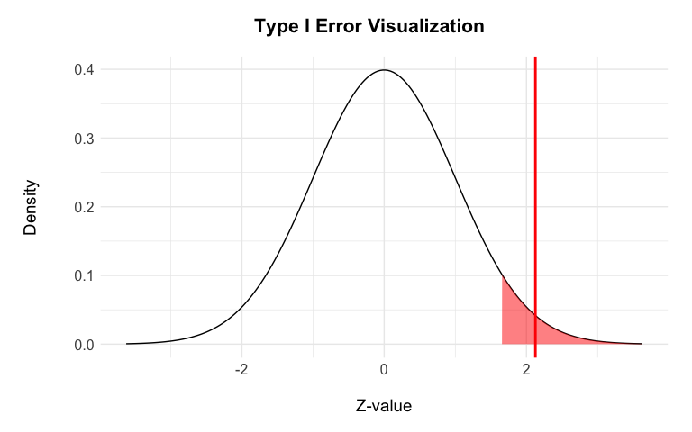

```r
visualize_ht(linear.model.z.test)
```

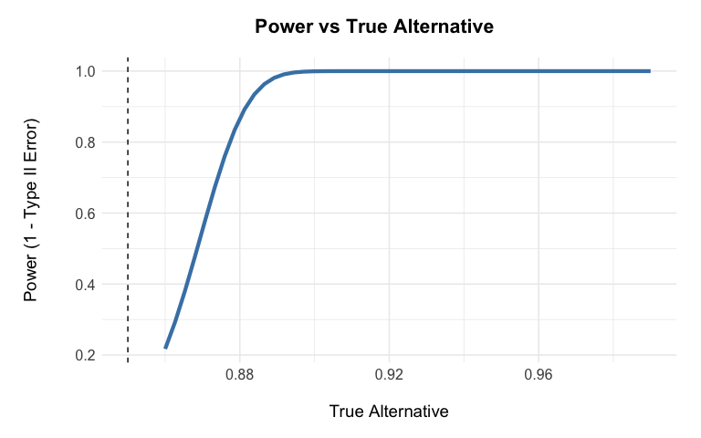

```r
visualize_ht(linear.model.z.test, type = "II")
```

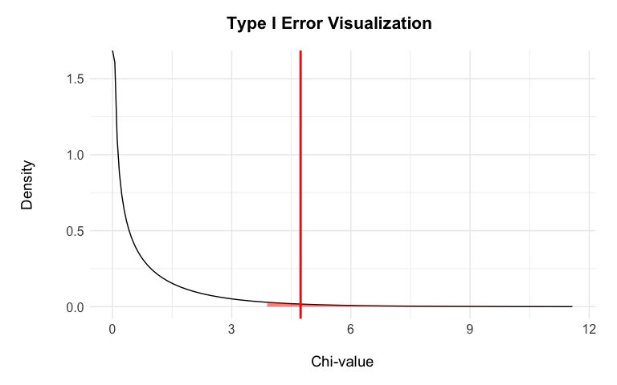

```r
visualize_ht(linear.model.lrt)
```

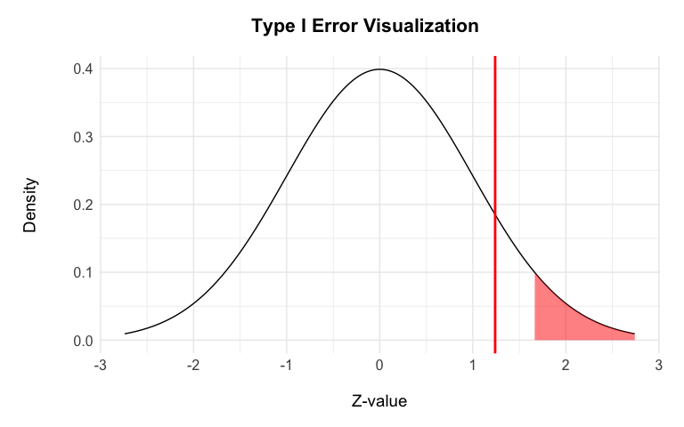

```r
visualize_ht(rbf.model.z.test)
```

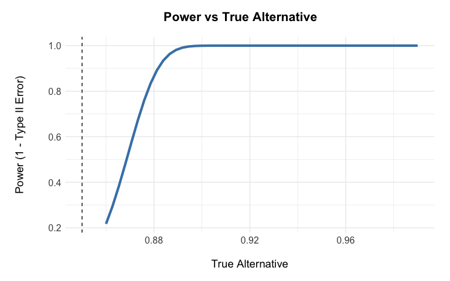

```r
visualize_ht(rbf.model.z.test, type = "II")
```

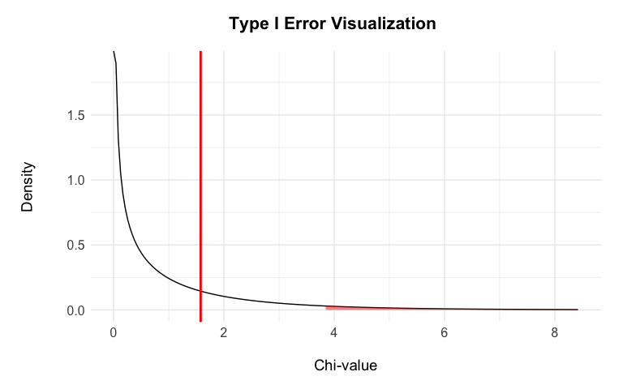

```r
visualize_ht(rbf.model.lrt)
```

## About this Package

This package was developed as a short learning project to fulfill course requirements. The goal was to provide hands-on experience in R package development, while exploring data science concepts. Therefore, it relies minimally on external libraries and contains areas that remain incomplete.